# Notebook 06 – Solutions

DSST289: Introduction to Data Science

Author

Erik Fredner

Published

September 17, 2024

## Getting Started

Before running this notebook, select “Session > Restart R and Clear Output” in the menu above to start a new R session. This will clear any old data sets and give us a blank slate to start with.

After starting a new session, run the following code chunk to load the libraries and data that we will be working with today.

I have set the options `include=FALSE` and `message=FALSE` to avoid cluttering the solutions with all the output from this code.

# Practice

## Load Datasets

We will work with the largest cities data sets:

```r
cities <- read_csv("../data/largest_cities.csv")
cities
```

| name | country | city_definition | population | city_pop | city_area | metro_pop | metro_area | urban_pop | urban_area | wiki | country_code2 | country_code3 | country_name_official | continent | lon | lat | koppen_code | koppen_main | city | num | cost_of_living | cost_rent | cost_groceries | cost_restaurant | local_pp |
| --- | --- | --- | --- | --- | --- | --- | --- | --- | --- | --- | --- | --- | --- | --- | --- | --- | --- | --- | --- | --- | --- | --- | --- | --- | --- |
| Tokyo | Japan | Metropolis prefecture | 37.400 | 13.515 | 2191.00 | 37.274 | 13452.0 | 38.505 | 8223 | Tokyo | JP | JPN | Japan | Asia | 139.692222 | 35.689722 | Cfa | Temperate | Tokyo, Japan | 18 | 86.87 | 38.00 | 83.42 | 56.70 | 89.70 |
| Delhi | India | National capital territory | 28.514 | 16.753 | 1484.00 | 29.000 | 3483.0 | 28.125 | 2240 | Delhi | IN | IND | India, Republic of | Asia | 77.230000 | 28.610000 | BSh | Dry | Delhi, India | 405 | 28.18 | 8.18 | 26.15 | 24.76 | 54.69 |
| Shanghai | China | Municipality | 25.582 | 24.183 | 6341.00 | NA | NA | 22.125 | 4015 | Shanghai | CN | CHN | China, People's Republic of | Asia | 121.474722 | 31.228611 | Cfa | Temperate | Shanghai, China | 235 | 50.07 | 35.67 | 52.50 | 36.48 | 54.40 |
| São Paulo | Brazil | Municipality | 21.650 | 12.252 | 1521.00 | 21.735 | 7947.0 | 20.935 | 3043 | Sao_Paulo | BR | BRA | Brazil, Federative Republic of | South America | -46.633333 | -23.550000 | Cfb | Temperate | Sao Paulo, Brazil | 257 | 45.52 | 16.28 | 33.29 | 39.70 | 31.97 |
| Mexico City | Mexico | City-state | 21.581 | 8.919 | 1485.00 | 20.893 | 7854.0 | 20.395 | 237 | Mexico_City | MX | MEX | Mexico, United Mexican States | North America | -99.133333 | 19.433333 | Cwb | Temperate | Mexico City, Mexico | 317 | 38.55 | 20.43 | 33.75 | 33.11 | 42.91 |
| Cairo | Egypt | Urban governorate | 20.076 | 9.500 | 3085.00 | NA | NA | 16.925 | 1917 | Cairo | EG | EGY | Egypt, Arab Republic of | Africa | 31.228889 | 30.058056 | BWh | Dry | Cairo, Egypt | 393 | 30.94 | 6.48 | 26.41 | 25.43 | 24.53 |
| Mumbai | India | Municipality | 19.980 | 12.478 | 603.00 | 24.400 | 4355.0 | 23.645 | 881 | Mumbai | IN | IND | India, Republic of | Asia | 72.825833 | 18.975000 | Am | Tropical | Mumbai, India | 399 | 28.84 | 21.02 | 26.86 | 26.61 | 41.68 |
| Beijing | China | Municipality | 19.618 | 21.707 | 16411.00 | NA | NA | 19.430 | 4144 | Beijing | CN | CHN | China, People's Republic of | Asia | 116.383333 | 39.916667 | Cwa | Temperate | Beijing, China | 261 | 44.89 | 34.97 | 43.08 | 35.85 | 60.72 |
| Dhaka | Bangladesh | Capital city | 19.578 | 14.399 | 338.00 | 14.543 | NA | 18.595 | 453 | Dhaka | BD | BGD | Bangladesh, People's Republic of | Asia | 90.388889 | 23.763889 | Aw | Tropical | Dhaka, Bangladesh | 370 | 34.52 | 5.69 | 31.58 | 20.02 | 33.45 |
| Osaka | Japan | Designated city | 19.281 | 2.725 | 225.00 | 19.303 | 13228.0 | 17.150 | 3004 | Osaka | JP | JPN | Japan | Asia | 135.502222 | 34.693889 | Cfa | Temperate | Osaka, Japan | 33 | 79.54 | 22.63 | 77.66 | 45.48 | 85.82 |

[output cut: 71 more lines]

We will also work with the entire U.S. cities data set:

```r
us <- read_csv("../data/us_city_population.csv")
us
```

| city | state | year | population | lon | lat |
| --- | --- | --- | --- | --- | --- |
| Anchorage, AK | AK | 1790 | 0.000 | -149.27435 | 61.17755 |
| Birmingham, AL | AL | 1790 | 0.000 | -86.79905 | 33.52744 |
| Huntsville, AL | AL | 1790 | 0.000 | -86.53900 | 34.78427 |
| Mobile, AL | AL | 1790 | 0.000 | -88.10023 | 30.66843 |
| Montgomery, AL | AL | 1790 | 0.000 | -86.26859 | 32.34625 |
| Little Rock, AR | AR | 1790 | 0.000 | -92.35856 | 34.72543 |
| Chandler, AZ | AZ | 1790 | 0.000 | -111.85494 | 33.28287 |
| Gilbert, AZ | AZ | 1790 | 0.000 | -111.74219 | 33.31021 |
| Glendale, AZ | AZ | 1790 | 0.000 | -112.18990 | 33.53311 |
| Mesa, AZ | AZ | 1790 | 0.000 | -111.71738 | 33.40193 |

[output cut: 6890 more lines]

Please refer to the previous notebooks for more information about these data sets.

## Creating new numeric features

Using the `cities` data set, create a new feature named `city_density` by dividing the city population (`city_pop`) by the city area (`city_area`). Use the `select` function to select the city name (`name`), population, area, and density.

```r
cities |>
  mutate(city_density = city_pop / city_area) |>
  select(name, city_pop, city_area, city_density)
```

| name | city_pop | city_area | city_density |
| --- | --- | --- | --- |
| Tokyo | 13.515 | 2191.00 | 6.168416e-03 |
| Delhi | 16.753 | 1484.00 | 1.128908e-02 |
| Shanghai | 24.183 | 6341.00 | 3.813752e-03 |
| São Paulo | 12.252 | 1521.00 | 8.055227e-03 |
| Mexico City | 8.919 | 1485.00 | 6.006061e-03 |
| Cairo | 9.500 | 3085.00 | 3.079417e-03 |
| Mumbai | 12.478 | 603.00 | 2.069320e-02 |
| Beijing | 21.707 | 16411.00 | 1.322710e-03 |
| Dhaka | 14.399 | 338.00 | 4.260059e-02 |
| Osaka | 2.725 | 225.00 | 1.211111e-02 |

[output cut: 71 more lines]

The numbers here are very small. What units is the feature `city_density` currently in? **Answer**: It is given in millions of people per square kilometer.

Below, modify your code by multiplying the city density by 1000.

```r
cities |>
  mutate(city_density = city_pop / city_area * 1000) |>
  select(name, city_pop, city_area, city_density)
```

| name | city_pop | city_area | city_density |
| --- | --- | --- | --- |
| Tokyo | 13.515 | 2191.00 | 6.16841625 |
| Delhi | 16.753 | 1484.00 | 11.28908356 |
| Shanghai | 24.183 | 6341.00 | 3.81375177 |
| São Paulo | 12.252 | 1521.00 | 8.05522682 |
| Mexico City | 8.919 | 1485.00 | 6.00606061 |
| Cairo | 9.500 | 3085.00 | 3.07941653 |
| Mumbai | 12.478 | 603.00 | 20.69320066 |
| Beijing | 21.707 | 16411.00 | 1.32271038 |
| Dhaka | 14.399 | 338.00 | 42.60059172 |
| Osaka | 2.725 | 225.00 | 12.11111111 |

[output cut: 71 more lines]

Now what are the units of the city density feature? **Answer**: Thousands of people per square kilometer.

Now, try to summarize the average city density by continent. You should notice that the results include some missing values:

```r
cities |>
  mutate(city_density = city_pop / city_area * 1000) |>
  group_by(continent) |>
  summarize(city_density = mean(city_density))
```

| continent | city_density |
| --- | --- |
| Africa | NA |
| Asia | NA |
| Europe | NA |
| North America | 3.868757 |
| South America | 7.868168 |

In the code block below, summarize the average city density by continent again but include the parameter `na.rm = TRUE` in the `mean()` function.

```r
cities |>
  mutate(city_density = city_pop / city_area * 1000) |>
  group_by(continent) |>
  summarize(city_density = mean(city_density, na.rm = TRUE))
```

| continent | city_density |
| --- | --- |
| Africa | 5.212897 |
| Asia | 10.617899 |
| Europe | 9.264345 |
| North America | 3.868757 |
| South America | 7.868168 |

Now, below, using the mutate verb, create a plot with city density on the x-axis and metro density on the y-axis. Use a log scale for the axes and include points and text repel labels with the city names.

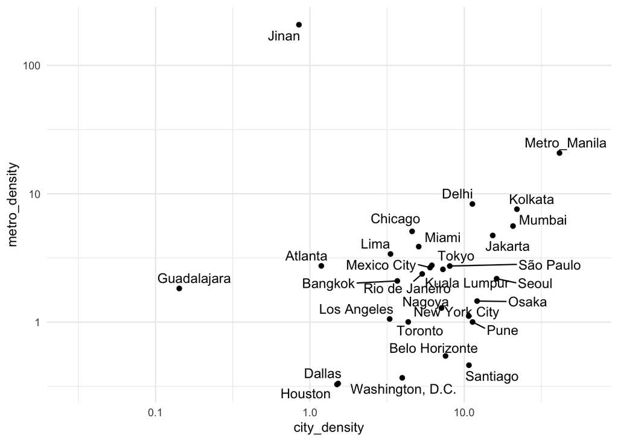

```r
cities |>
  mutate(city_density = city_pop / city_area * 1000) |>
  mutate(metro_density = metro_pop / metro_area * 1000) |>
  ggplot(aes(city_density, metro_density)) +
  geom_point() +
  geom_text_repel(aes(label = name)) +
  scale_x_log10() +
  scale_y_log10()
```

What two outliers stick out in this plot? **Answer**: Guadalajara and Jinan have a much higher metro density than would be expect based on the city density.

## Creating new categorical features

Create a bar plot showing the counts of the the `koppen_code` feature in the `cities` data set. Order the groups’ categories ordered from the biggest to the smallest. The labels are short so put the categorical variable on the x-axis.

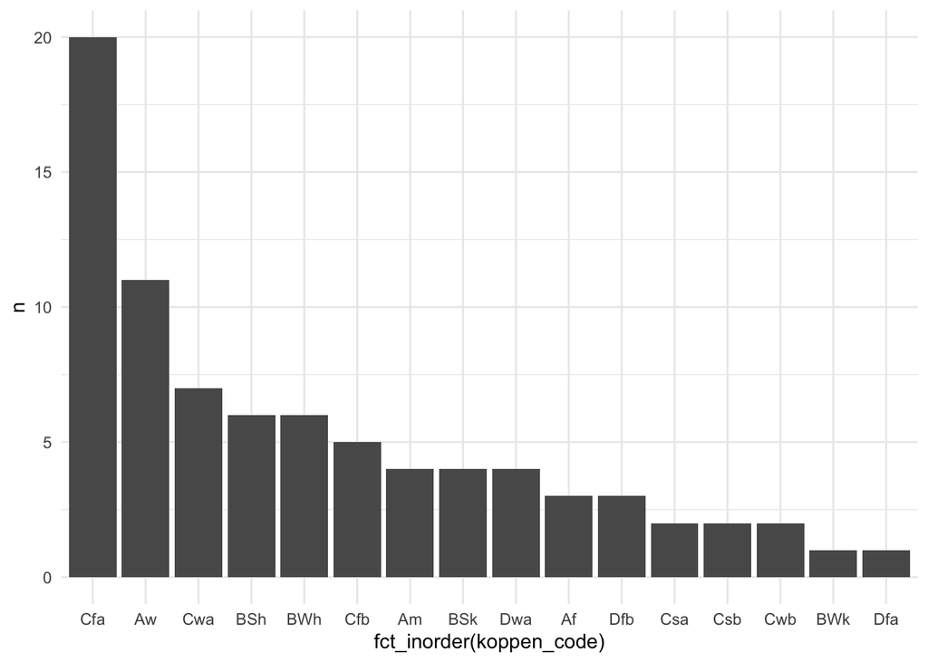

```r
cities |>
  count(koppen_code) |>
  arrange(desc(n)) |>
  ggplot(aes(x = fct_inorder(koppen_code), y = n)) +
  geom_col()
```

In the code below, create a new feature called `hemisphere` which is equal to “North” for cities with a latitude above zero and “South” for cities below zero. Pipe the data to a plot and color the cities by their hemisphere to verify that your code is correct.

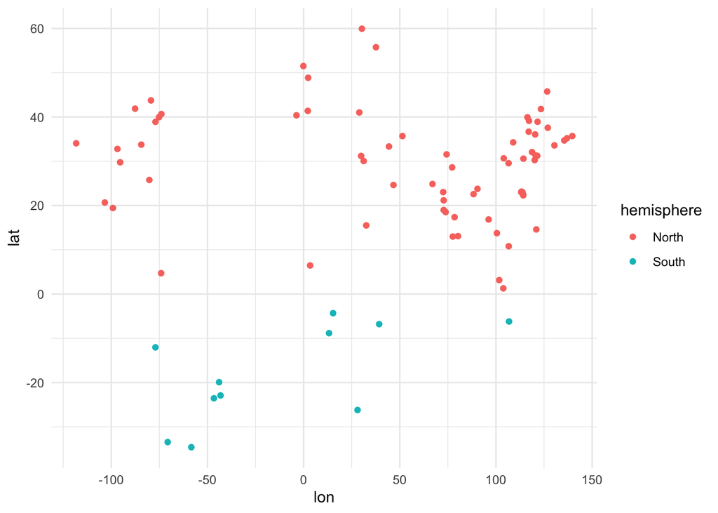

```r
cities |>
  mutate(hemisphere = if_else(lat > 0, "North", "South")) |>
  ggplot(aes(lon, lat)) +
  geom_point(aes(color = hemisphere))
```

Repeat this process below, but this time create a feature called “quadrant” that is equal to “NE”, “NW”, “SE”, and “SE” depending on the sign of the latitude and longitude features. The easiest way to do this is to start by defining a default value and them fill in the quadrants with four uses of the `if_else` function. Note: use the `&` operator to combine two conditions (i.e., `(lat > 0) & (lon > 0)`).

```r
cities |>
  mutate(quadrant = "default") |>
  mutate(quadrant = if_else((lat > 0) & (lon > 0), "NE", quadrant)) |>
  mutate(quadrant = if_else((lat > 0) & (lon < 0), "NW", quadrant)) |>
  mutate(quadrant = if_else((lat < 0) & (lon > 0), "SE", quadrant)) |>
  mutate(quadrant = if_else((lat < 0) & (lon < 0), "SW", quadrant)) |>
  select(country, quadrant)
```

| country | quadrant |
| --- | --- |
| Japan | NE |
| India | NE |
| China | NE |
| Brazil | SW |
| Mexico | NW |
| Egypt | NE |
| India | NE |
| China | NE |
| Bangladesh | NE |
| Japan | NE |

[output cut: 71 more lines]

Now, try rewriting the code above to use the `case_when` function instead of multiple `if_else` statements.

```r
cities |>
  mutate(
    quadrant = case_when(
      (lat > 0) & (lon > 0) ~ "NE",
      (lat > 0) & (lon < 0) ~ "NW",
      (lat < 0) & (lon > 0) ~ "SE",
      (lat < 0) & (lon < 0) ~ "SW",
      TRUE ~ "default"
    )
  )
```

| name | country | city_definition | population | city_pop | city_area | metro_pop | metro_area | urban_pop | urban_area | wiki | country_code2 | country_code3 | country_name_official | continent | lon | lat | koppen_code | koppen_main | city | num | cost_of_living | cost_rent | cost_groceries | cost_restaurant | local_pp | quadrant |
| --- | --- | --- | --- | --- | --- | --- | --- | --- | --- | --- | --- | --- | --- | --- | --- | --- | --- | --- | --- | --- | --- | --- | --- | --- | --- | --- |
| Tokyo | Japan | Metropolis prefecture | 37.400 | 13.515 | 2191.00 | 37.274 | 13452.0 | 38.505 | 8223 | Tokyo | JP | JPN | Japan | Asia | 139.692222 | 35.689722 | Cfa | Temperate | Tokyo, Japan | 18 | 86.87 | 38.00 | 83.42 | 56.70 | 89.70 | NE |
| Delhi | India | National capital territory | 28.514 | 16.753 | 1484.00 | 29.000 | 3483.0 | 28.125 | 2240 | Delhi | IN | IND | India, Republic of | Asia | 77.230000 | 28.610000 | BSh | Dry | Delhi, India | 405 | 28.18 | 8.18 | 26.15 | 24.76 | 54.69 | NE |
| Shanghai | China | Municipality | 25.582 | 24.183 | 6341.00 | NA | NA | 22.125 | 4015 | Shanghai | CN | CHN | China, People's Republic of | Asia | 121.474722 | 31.228611 | Cfa | Temperate | Shanghai, China | 235 | 50.07 | 35.67 | 52.50 | 36.48 | 54.40 | NE |
| São Paulo | Brazil | Municipality | 21.650 | 12.252 | 1521.00 | 21.735 | 7947.0 | 20.935 | 3043 | Sao_Paulo | BR | BRA | Brazil, Federative Republic of | South America | -46.633333 | -23.550000 | Cfb | Temperate | Sao Paulo, Brazil | 257 | 45.52 | 16.28 | 33.29 | 39.70 | 31.97 | SW |
| Mexico City | Mexico | City-state | 21.581 | 8.919 | 1485.00 | 20.893 | 7854.0 | 20.395 | 237 | Mexico_City | MX | MEX | Mexico, United Mexican States | North America | -99.133333 | 19.433333 | Cwb | Temperate | Mexico City, Mexico | 317 | 38.55 | 20.43 | 33.75 | 33.11 | 42.91 | NW |
| Cairo | Egypt | Urban governorate | 20.076 | 9.500 | 3085.00 | NA | NA | 16.925 | 1917 | Cairo | EG | EGY | Egypt, Arab Republic of | Africa | 31.228889 | 30.058056 | BWh | Dry | Cairo, Egypt | 393 | 30.94 | 6.48 | 26.41 | 25.43 | 24.53 | NE |
| Mumbai | India | Municipality | 19.980 | 12.478 | 603.00 | 24.400 | 4355.0 | 23.645 | 881 | Mumbai | IN | IND | India, Republic of | Asia | 72.825833 | 18.975000 | Am | Tropical | Mumbai, India | 399 | 28.84 | 21.02 | 26.86 | 26.61 | 41.68 | NE |
| Beijing | China | Municipality | 19.618 | 21.707 | 16411.00 | NA | NA | 19.430 | 4144 | Beijing | CN | CHN | China, People's Republic of | Asia | 116.383333 | 39.916667 | Cwa | Temperate | Beijing, China | 261 | 44.89 | 34.97 | 43.08 | 35.85 | 60.72 | NE |
| Dhaka | Bangladesh | Capital city | 19.578 | 14.399 | 338.00 | 14.543 | NA | 18.595 | 453 | Dhaka | BD | BGD | Bangladesh, People's Republic of | Asia | 90.388889 | 23.763889 | Aw | Tropical | Dhaka, Bangladesh | 370 | 34.52 | 5.69 | 31.58 | 20.02 | 33.45 | NE |
| Osaka | Japan | Designated city | 19.281 | 2.725 | 225.00 | 19.303 | 13228.0 | 17.150 | 3004 | Osaka | JP | JPN | Japan | Asia | 135.502222 | 34.693889 | Cfa | Temperate | Osaka, Japan | 33 | 79.54 | 22.63 | 77.66 | 45.48 | 85.82 | NE |

[output cut: 71 more lines]

Now, pipe the data into a plot colored by quadrant to verify your work.

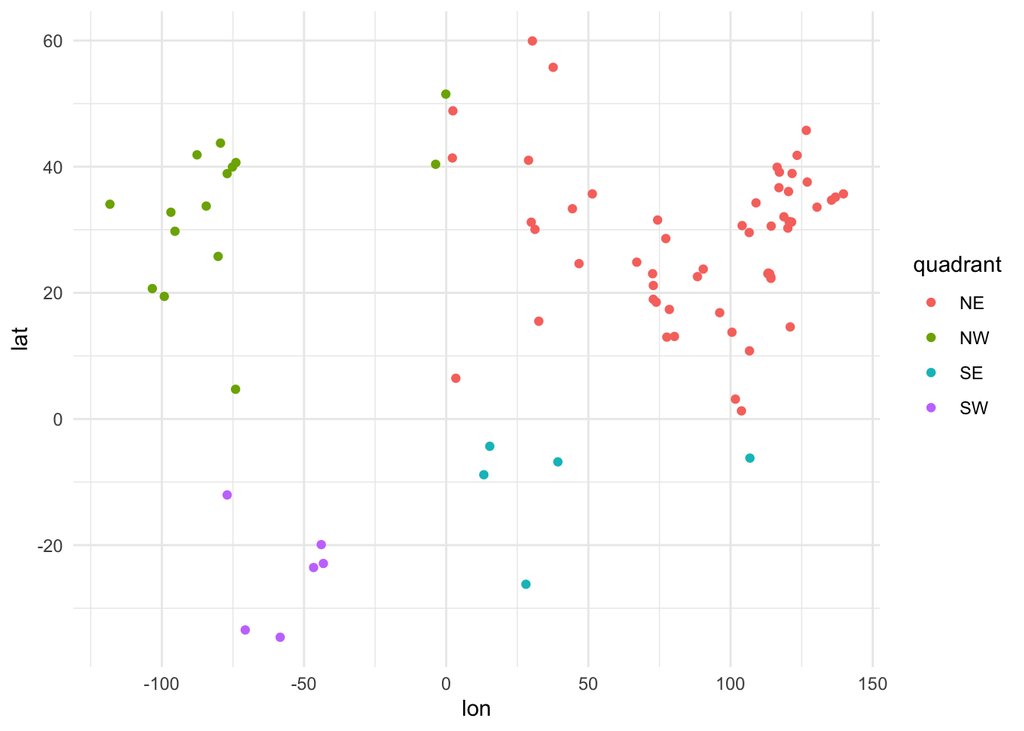

```r
cities |>
  mutate(
    quadrant = case_when(
      (lat > 0) & (lon > 0) ~ "NE",
      (lat > 0) & (lon < 0) ~ "NW",
      (lat < 0) & (lon > 0) ~ "SE",
      (lat < 0) & (lon < 0) ~ "SW",
      TRUE ~ "default"
    )
  ) |>
  ggplot(aes(lon, lat)) +
  geom_point(aes(color = quadrant))
```

## Grouped Mutate

To conclude, we will apply a few grouped versions of the mutate verb. To make sure we understand how this works, take the `us` data set, group by city, and compute the maximum value of the population feature for each city.

```r
us |>
  group_by(city) |>
  mutate(population_max = max(population))
```

| city | state | year | population | lon | lat | population_max |
| --- | --- | --- | --- | --- | --- | --- |
| Anchorage, AK | AK | 1790 | 0.000 | -149.27435 | 61.17755 | 291.826 |
| Birmingham, AL | AL | 1790 | 0.000 | -86.79905 | 33.52744 | 340.887 |
| Huntsville, AL | AL | 1790 | 0.000 | -86.53900 | 34.78427 | 180.105 |
| Mobile, AL | AL | 1790 | 0.000 | -88.10023 | 30.66843 | 200.452 |
| Montgomery, AL | AL | 1790 | 0.000 | -86.26859 | 32.34625 | 205.764 |
| Little Rock, AR | AR | 1790 | 0.000 | -92.35856 | 34.72543 | 193.524 |
| Chandler, AZ | AZ | 1790 | 0.000 | -111.85494 | 33.28287 | 236.123 |
| Gilbert, AZ | AZ | 1790 | 0.000 | -111.74219 | 33.31021 | 208.453 |
| Glendale, AZ | AZ | 1790 | 0.000 | -112.18990 | 33.53311 | 226.721 |
| Mesa, AZ | AZ | 1790 | 0.000 | -111.71738 | 33.40193 | 439.041 |

[output cut: 6890 more lines]

Note that this added a new column to a copy of the original data set showing the largest population for each city at any point in time.

Building off of this approach, construct a scatter plot that shows the population of cities in 2010 on the x-axis and the percentage of the 2010 population compared to the maximum population of the city from 1790-2010. Filter to only include cities that are less than 70% of their maximum size in 2010. Use a text repel layer to label each city. (Note: This will require at least two different calls to the mutate function).

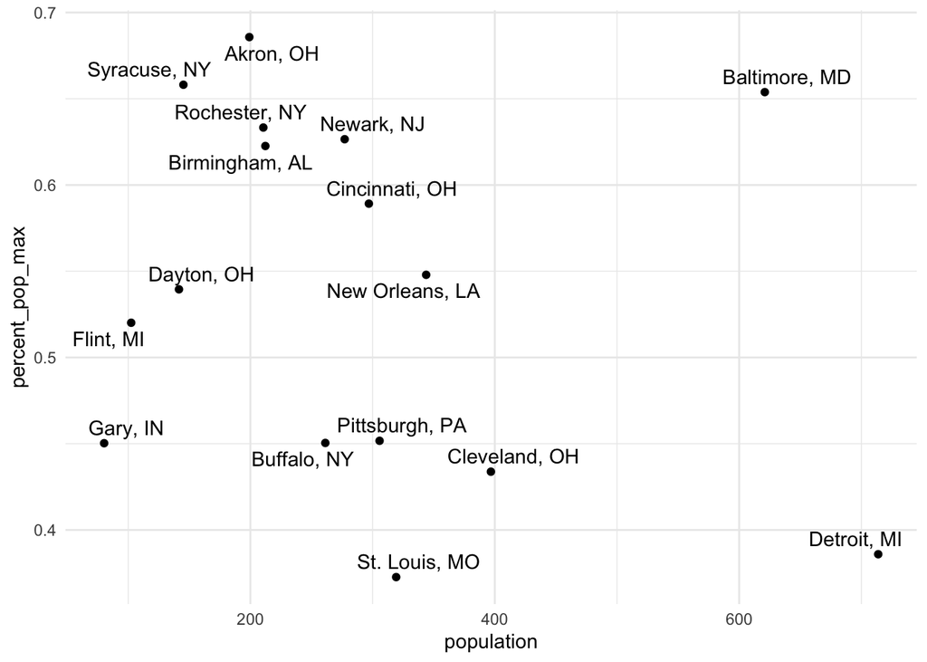

```r
us |>
  group_by(city) |>
  mutate(population_max = max(population)) |>
  filter(year == 2010) |>
  mutate(percent_pop_max = population / population_max) |>
  filter(percent_pop_max < 0.7) |>
  ggplot(aes(population, percent_pop_max)) +
  geom_point() +
  geom_text_repel(aes(label = city))
```